# Notebook Structure

1. Import necessary dependencies
2. Create dataset
3. Pairplot visualization for the numerical features
4. Create detailed pairplot with multiple combination
5. How to interpret pairplot

# 1. Import necessary dependencies

```python
# libraries & dataset
import matplotlib.pyplot as plt
import numpy as np
import seaborn as sns
import pandas as pd


sns.set_theme(style="darkgrid")
```

# 2. Create the dataset

```python
# 1. Create a dataset with around 10 numerical variables
# Using a dictionary to create the data, then converting to a DataFrame
data = {
    'StockPrice': np.random.normal(100, 15, 100),  # Example stock price
    'EPS': np.random.normal(5, 2, 100),             # Earnings per share
    'PE_Ratio': np.random.normal(20, 5, 100),        # Price-to-earnings ratio
    'DebtToEquity': np.random.uniform(0, 2, 100),   # Debt-to-equity ratio
    'ROA': np.random.normal(0.05, 0.02, 100),       # Return on assets
    'ROE': np.random.normal(0.10, 0.05, 100),      # Return on equity
    'MarketCap': np.random.lognormal(10, 2, 100),   # Market capitalization
    'RevenueGrowth': np.random.normal(0.08, 0.03, 100), # Revenue growth rate
    'DividendYield': np.random.uniform(0, 0.05, 100), # Dividend yield
    'Beta': np.random.normal(1, 0.3, 100)           # Beta coefficient
}
```

```python
df = pd.DataFrame(data)
df
```

|  | StockPrice | EPS | PE_Ratio | DebtToEquity | ROA | ROE | MarketCap | RevenueGrowth | DividendYield | Beta |
| --- | --- | --- | --- | --- | --- | --- | --- | --- | --- | --- |
| 0 | 114.659778 | 6.867890 | 24.538091 | 0.665562 | 0.031830 | 0.094451 | 11728.845734 | 0.105073 | 0.037172 | 1.067162 |
| 1 | 96.083589 | 5.976989 | 20.561811 | 1.114810 | 0.060783 | 0.069116 | 937660.216728 | 0.084021 | 0.026641 | 0.539494 |
| 2 | 70.055856 | 9.723223 | 20.227949 | 1.414031 | 0.069567 | 0.037640 | 561370.818797 | 0.087219 | 0.043033 | 1.161255 |
| 3 | 98.183550 | 4.342676 | 19.613193 | 1.325136 | 0.025536 | 0.119300 | 3176.272534 | 0.047401 | 0.034746 | 1.011551 |
| 4 | 69.898320 | 1.047999 | 28.792089 | 1.615436 | 0.083890 | 0.097520 | 109146.978118 | 0.053117 | 0.000528 | 1.432176 |
| ... | ... | ... | ... | ... | ... | ... | ... | ... | ... | ... |
| 95 | 95.952392 | 4.353138 | 12.055264 | 1.293674 | 0.041694 | 0.084069 | 9282.743984 | 0.048091 | 0.000833 | 0.844724 |
| 96 | 95.659534 | 7.894071 | 27.400544 | 1.249959 | 0.067115 | 0.154112 | 5142.959004 | 0.059166 | 0.016947 | 0.910522 |
| 97 | 102.355664 | 7.932911 | 17.935042 | 1.276701 | 0.023217 | 0.136034 | 617926.546318 | 0.051350 | 0.039783 | 0.840433 |
| 98 | 115.290790 | 7.540833 | 23.925626 | 0.614291 | 0.053195 | 0.070643 | 28085.665305 | 0.081103 | 0.003874 | 0.920272 |
| 99 | 95.135594 | 4.075485 | 14.851669 | 1.719359 | 0.036450 | 0.061053 | 60773.473192 | 0.090837 | 0.014116 | 0.747161 |

100 rows × 10 columns

```python
df.shape
```

```
(100, 10)
```

# 3. Pairplot visualization for the numerical features

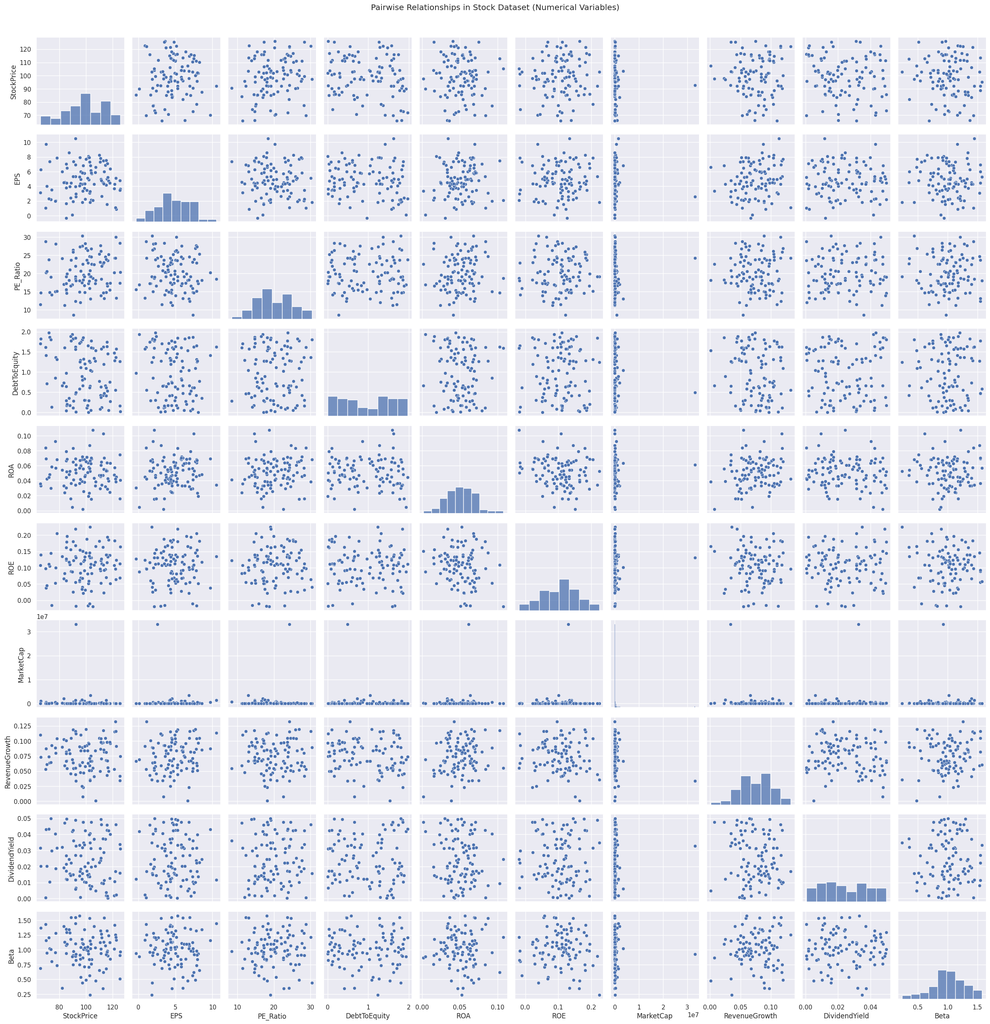

```python
# Use pairplot for bivariate analysis of numerical variables
# By default, pairplot will plot pairwise relationships for all numerical columns
sns.pairplot(df)
plt.suptitle("Pairwise Relationships in Stock Dataset (Numerical Variables)", y=1.02)
plt.show()
```

# 4. Create detailed pairplot with multiple combination

```python
# Load the iris dataset
iris = sns.load_dataset('iris')
iris.head()
```

|  | sepal_length | sepal_width | petal_length | petal_width | species |
| --- | --- | --- | --- | --- | --- |
| 0 | 5.1 | 3.5 | 1.4 | 0.2 | setosa |
| 1 | 4.9 | 3.0 | 1.4 | 0.2 | setosa |
| 2 | 4.7 | 3.2 | 1.3 | 0.2 | setosa |
| 3 | 4.6 | 3.1 | 1.5 | 0.2 | setosa |
| 4 | 5.0 | 3.6 | 1.4 | 0.2 | setosa |

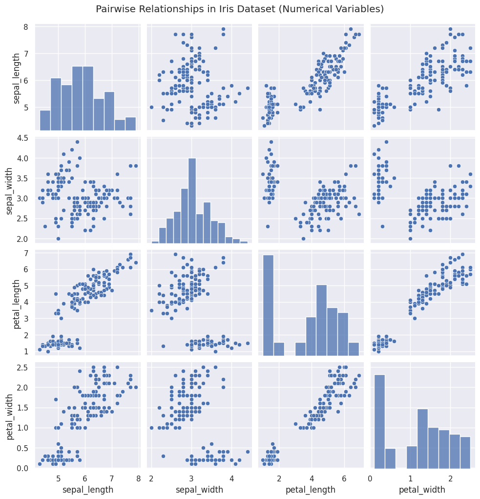

```python
# Use pairplot for bivariate analysis of numerical variables
# By default, pairplot will plot pairwise relationships for all numerical columns
sns.pairplot(iris)
plt.suptitle("Pairwise Relationships in Iris Dataset (Numerical Variables)", y=1.02)
plt.show()
```

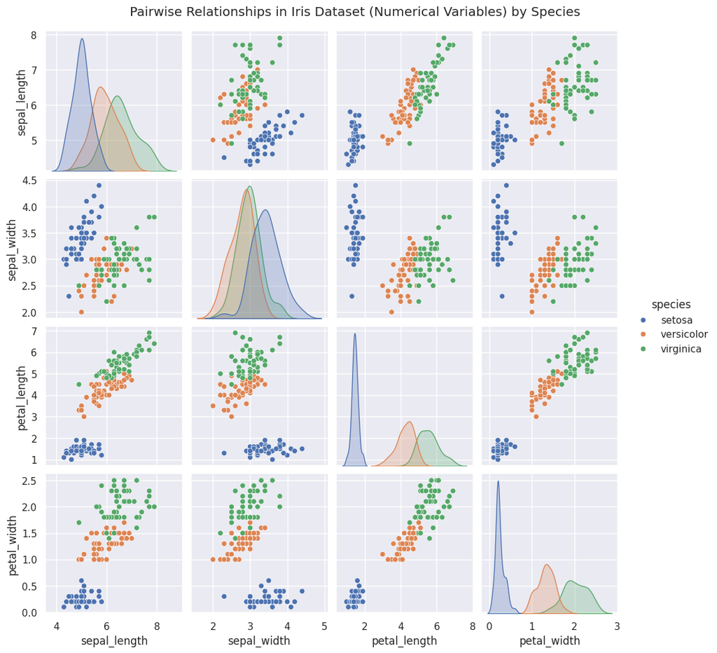

```python
# If you want to highlight the species, you can use the 'hue' parameter
sns.pairplot(iris, hue='species')
plt.suptitle("Pairwise Relationships in Iris Dataset (Numerical Variables) by Species", y=1.02)
plt.show()
```

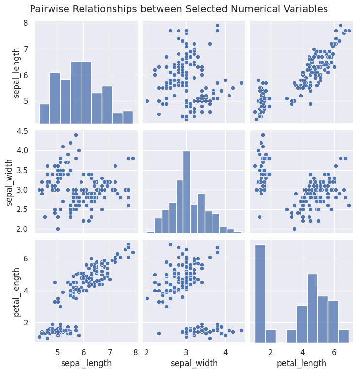

```python
# If you only want to see the relationships between specific numerical columns,
# you can specify them explicitly
numerical_cols = ['sepal_length', 'sepal_width', 'petal_length']
sns.pairplot(iris[numerical_cols])
plt.suptitle("Pairwise Relationships between Selected Numerical Variables", y=1.02)
plt.show()
```

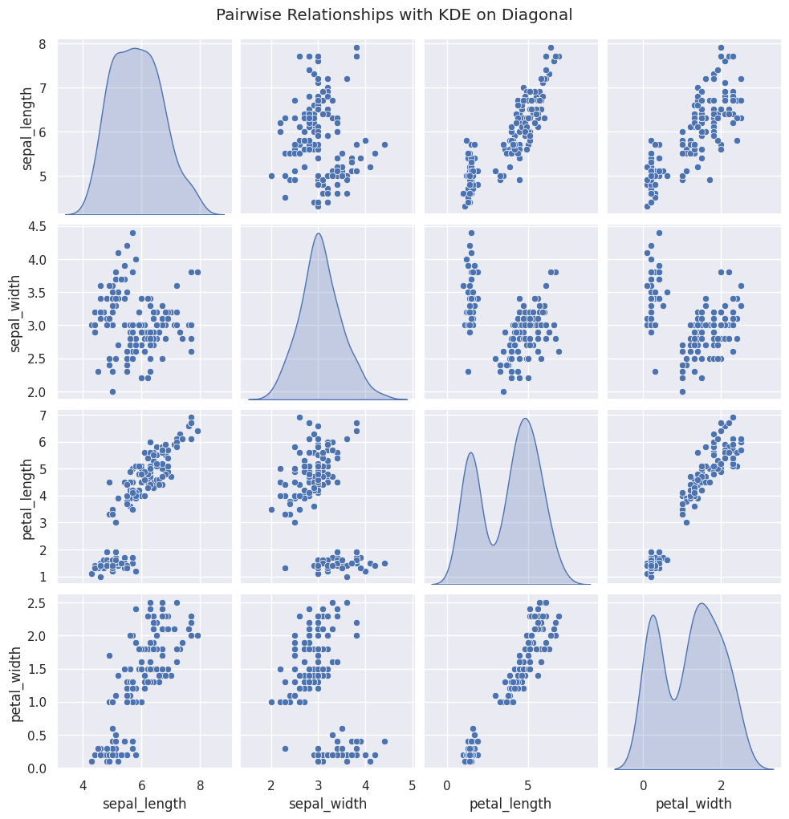

```python
# customize the diagonal plots (univariate distributions)
sns.pairplot(iris, diag_kind='kde') # 'kde' for kernel density estimate
plt.suptitle("Pairwise Relationships with KDE on Diagonal", y=1.02)
plt.show()
```

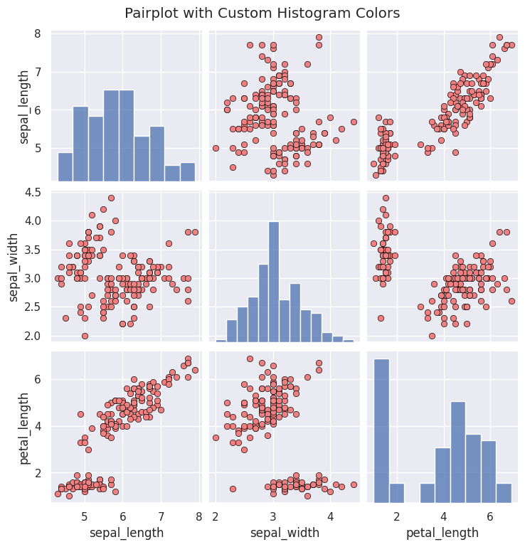

```python
# Histogram
sns.pairplot(iris[numerical_cols], diag_kind='hist', plot_kws={'color': 'lightcoral', 'edgecolor': 'black'})
plt.suptitle("Pairplot with Custom Histogram Colors", y=1.02)
plt.show()
```

# 5. How to interpret a pairplot

### Pairplot with hue

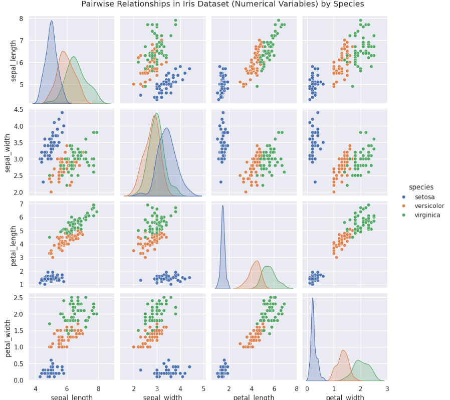

1. The Diagonal Plots (Univariate Distributions):
- Along the main diagonal (from top-left to bottom-right), you see Kernel Density Estimate (KDE) plots for each of the four numerical features: sepal length, sepal width, petal length, and petal width.
- Each KDE plot shows the distribution of that particular feature for each of the three species, using different colors (blue for setosa, orange for versicolor, and green for virginica, as indicated by the legend).
- Interpretation of Diagonal:
  - Sepal Length: Setosa tends to have a smaller sepal length compared to versicolor and virginica, which have overlapping but generally larger sepal lengths.
  - Sepal Width: Setosa has a relatively wider sepal compared to versicolor and virginica, which have more overlap in their sepal width distributions.
  - Petal Length: There's a clear separation here. Setosa has significantly shorter petals, while versicolor has intermediate petal lengths, and virginica has the longest petals.
  - Petal Width: Similar to petal length, setosa has the narrowest petals, versicolor has intermediate widths, and virginica has the widest petals.
2. The Off-Diagonal Plots (Bivariate Relationships - Scatter Plots):
- The off-diagonal plots are scatter plots showing the relationship between each pair of numerical features. For example, the plot in the first row, second column shows the relationship between 'sepal_length' (y-axis) and 'sepal_width' (x-axis).
- Again, the points are colored by species, allowing you to see if there are different patterns for each species.
- Interpretation of Off-Diagonal Plots (Examples):
  - Sepal Length vs. Sepal Width (Top Row, Second Column): There doesn't appear to be a very strong linear correlation overall. However, you can observe that setosa tends to have a combination of shorter but wider sepals compared to the other two species. Versicolor and virginica show more overlap.
  - Sepal Length vs. Petal Length (Top Row, Third Column): There's a clear positive correlation. As sepal length increases, petal length also tends to increase. You can also see distinct clusters for each species, with setosa having shorter sepal and petal lengths, followed by versicolor, and then virginica with the largest values.
  - Sepal Length vs. Petal Width (Top Row, Fourth Column): Similar to petal length, there's a positive correlation with sepal length. The species are also well-separated.
  - Sepal Width vs. Petal Length (Second Row, Third Column): There's a negative trend for setosa (wider sepals tend to have shorter petals within that species). Versicolor and virginica show a positive trend, though with some overlap.
  - Petal Length vs. Petal Width (Third Row, Fourth Column): This shows a very strong positive correlation. As petal length increases, petal width also strongly increases. The three species form distinct, well-separated clusters. This is one of the most distinguishing relationships in the Iris dataset.

Overall Insights from the Pair Plot:

- Species Differentiation: The pair plot clearly demonstrates that the four numerical features can be quite effective in distinguishing between the three Iris species. In many of the scatter plots (especially those involving petal length and petal width), the species form distinct clusters with minimal overlap.
- Correlations: You can visually assess the correlations between different features. For example, petal length and petal width are highly positively correlated. Sepal length and petal length also show a positive correlation. Distribution of Features: The diagonal KDE plots provide insights into the distribution of each feature for each species, highlighting differences in central tendency and spread.

In summary, this pair plot provides a rich visual summary of the relationships between the numerical variables in the Iris dataset and how these relationships vary across the different species. It's a powerful tool for initial data exploration and understanding the potential for using these features in classification tasks.